# Genome-wide methylation analysis report

# Genome-wide methylation analysis report

- study: Pleural cfDNAm analysis of lung_other_maligvariable
- author: Paul Yousefi
- date: 08 October, 2026

## Parameters

```
## $sig.threshold
## [1] 2.121143e-07
##
## $max.plots
## [1] 10
##
## $qq.inflation.method
## [1] "median"
##
## $practical.threshold
## [1] 1.970517e-05
```

## Sample characteristics

For continuous or ordinal variables, the “mean” column provides the mean and the “sd/%” column the standard deviation of the variable. For categorical variables, the “mean” column provides the number of samples with the given “value” and the “sd/%” column the percentage of samples with the given “value”.

| variable | value | mean | sd.. |
| --- | --- | --- | --- |
| lung_other_malig |  | 0.2882353 | 0.4542793 |
| sv1 |  | 1.338511e-18 | 0.07692308 |
| sv2 |  | -6.693354e-19 | 0.07692308 |
| sv3 |  | 5.9551e-18 | 0.07692308 |
| sv4 |  | -4.642458e-18 | 0.07692308 |
| sv5 |  | 5.596397e-18 | 0.07692308 |
| sv6 |  | -6.73445e-18 | 0.07692308 |
| sv7 |  | 6.164088e-18 | 0.07692308 |
| sv8 |  | -1.405796e-17 | 0.07692308 |
| sv9 |  | -2.24455e-17 | 0.07692308 |
| sv10 |  | -1.33806e-15 | 0.07692308 |

## Covariate associations

### Covariate sv1

statistics

| var1 | var2 | F | p-value | R | p-value |
| --- | --- | --- | --- | --- | --- |
| lung_other_malig | sv1 | 2.047404 | 0.1543234 | -0.1552124 | 0.0432739 |

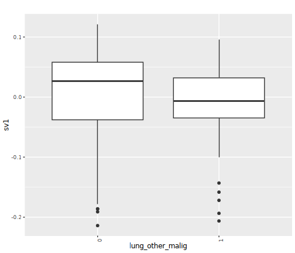

### Covariate sv2

statistics

| var1 | var2 | F | p-value | R | p-value |
| --- | --- | --- | --- | --- | --- |
| lung_other_malig | sv2 | 0.171871 | 0.6789832 | -0.0101887 | 0.8950888 |

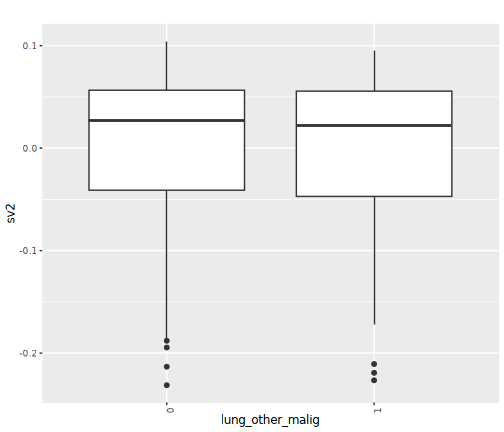

### Covariate sv3

statistics

| var1 | var2 | F | p-value | R | p-value |
| --- | --- | --- | --- | --- | --- |
| lung_other_malig | sv3 | 0.0001907 | 0.9889997 | -0.0120412 | 0.8761549 |

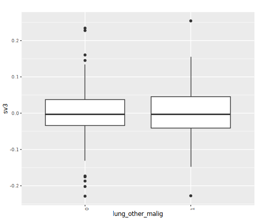

### Covariate sv4

statistics

| var1 | var2 | F | p-value | R | p-value |
| --- | --- | --- | --- | --- | --- |
| lung_other_malig | sv4 | 0.7268751 | 0.3951118 | -0.0011909 | 0.9877029 |

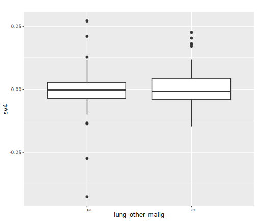

### Covariate sv5

statistics

| var1 | var2 | F | p-value | R | p-value |
| --- | --- | --- | --- | --- | --- |
| lung_other_malig | sv5 | 3.74e-05 | 0.9951253 | -0.0022495 | 0.9767745 |

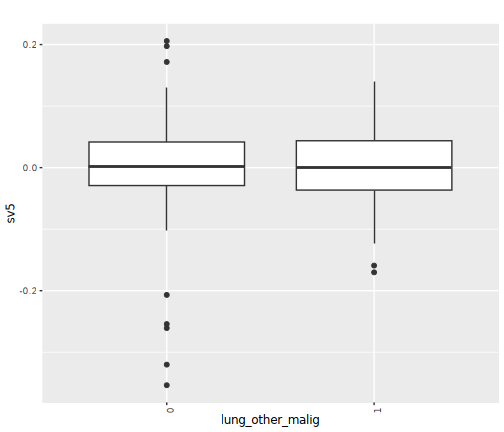

### Covariate sv6

statistics

| var1 | var2 | F | p-value | R | p-value |
| --- | --- | --- | --- | --- | --- |
| lung_other_malig | sv6 | 1.124755 | 0.2904193 | -0.1033426 | 0.179896 |

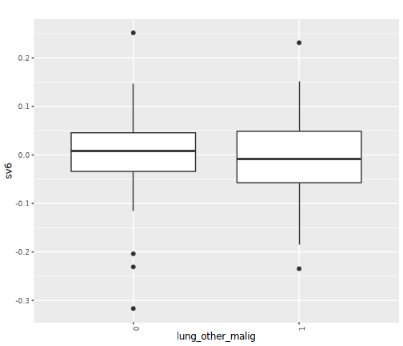

### Covariate sv7

statistics

| var1 | var2 | F | p-value | R | p-value |
| --- | --- | --- | --- | --- | --- |
| lung_other_malig | sv7 | 0.0382668 | 0.8451448 | 0.0930216 | 0.2276159 |

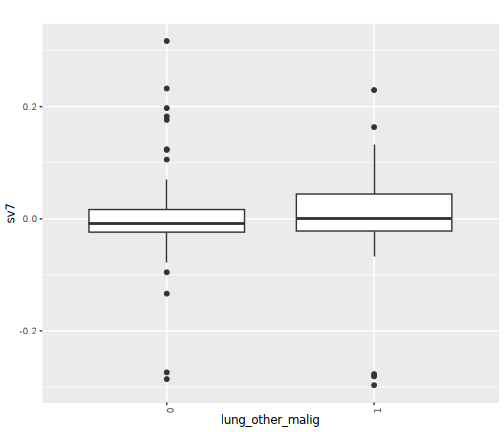

### Covariate sv8

statistics

| var1 | var2 | F | p-value | R | p-value |
| --- | --- | --- | --- | --- | --- |
| lung_other_malig | sv8 | 0.028973 | 0.8650463 | -0.0467093 | 0.5452776 |

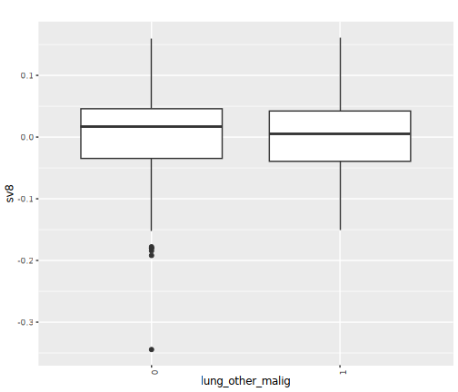

### Covariate sv9

statistics

| var1 | var2 | F | p-value | R | p-value |
| --- | --- | --- | --- | --- | --- |
| lung_other_malig | sv9 | 0.2340115 | 0.6291951 | 0.0411518 | 0.5941575 |

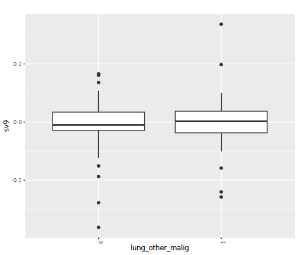

### Covariate sv10

statistics

| var1 | var2 | F | p-value | R | p-value |
| --- | --- | --- | --- | --- | --- |
| lung_other_malig | sv10 | 0.0005502 | 0.9813142 | -0.0403579 | 0.6012992 |

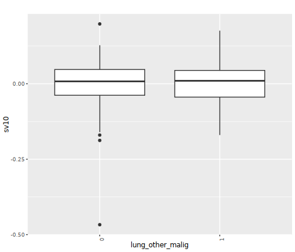

## QQ plots

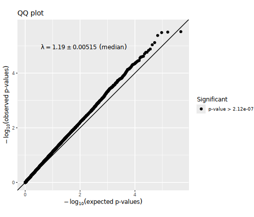

## Manhattan plots

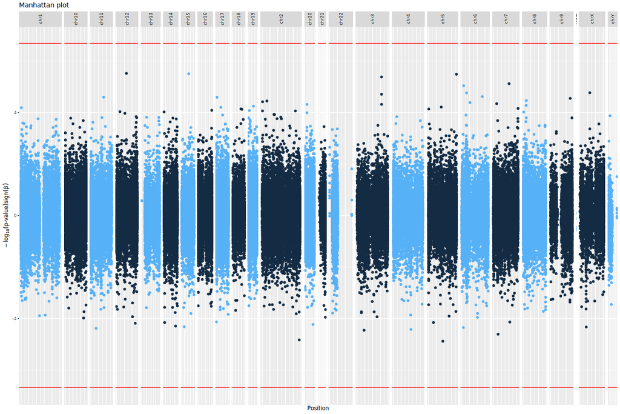

## Significant CpG sites

There were 0 CpG sites with association p-values < 2.1211427 × 10<sup>-7</sup>. These are listed in the file associations.csv.

Below are the 10 CpG sites with association p-values < 1.9705169 × 10<sup>-5</sup> in the regression model.

|  | chromosome | position | estimate | p.value | p.adjust |
| --- | --- | --- | --- | --- | --- |
| cg27125657 | chrX | 63534931 | 0.0991521 | 1.72e-05 | 1.0000000 |
| cg08540953 | chr7 | 100815796 | 0.0343826 | 7.60e-06 | 1.0000000 |
| cg04192879 | chr5 | 92929473 | -0.0859648 | 1.31e-05 | 1.0000000 |
| cg26771391 | chr6 | 12208704 | 0.0915057 | 9.20e-06 | 1.0000000 |
| cg16845126 | chr2 | 238773788 | -0.0529564 | 1.47e-05 | 1.0000000 |
| cg19919789 | chr15 | 67306302 | 0.0896314 | 3.20e-06 | 0.7449091 |
| cg23900141 | chr6 | 31085004 | 0.0638172 | 1.74e-05 | 1.0000000 |
| cg04492927 | chr5 | 180480817 | 0.0511030 | 3.30e-06 | 0.7742652 |
| cg17477445 | chr12 | 64062526 | 0.0517422 | 3.00e-06 | 0.7176867 |
| cg26129769 | chr3 | 157824148 | 0.0821592 | 4.20e-06 | 0.9878081 |

Plots of these sites follow, one for each covariate set. “p[lm]” denotes the p-value obtained using a linear model and “p[beta]” the p-value obtained using beta regression.

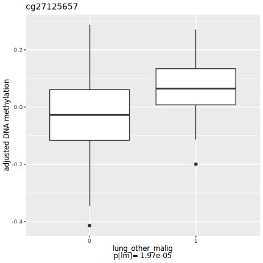

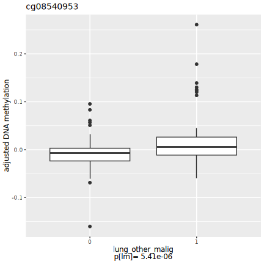

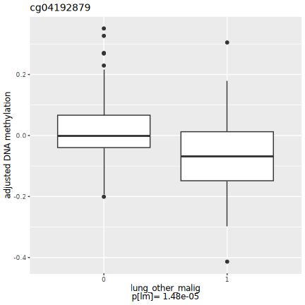

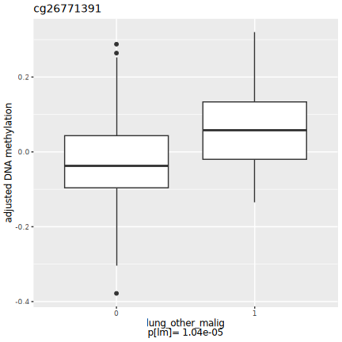

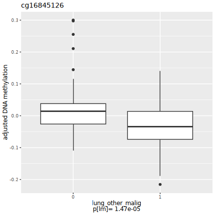

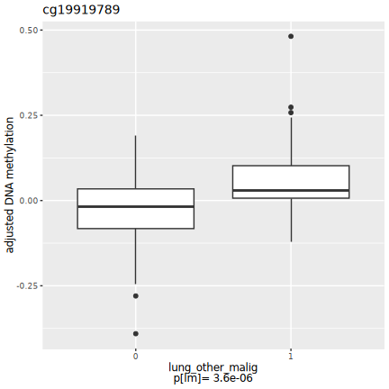

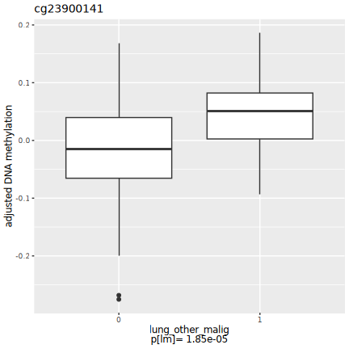

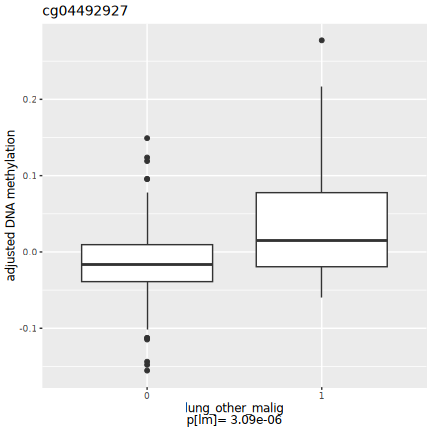

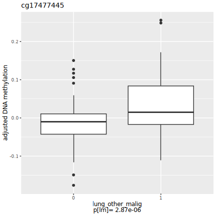

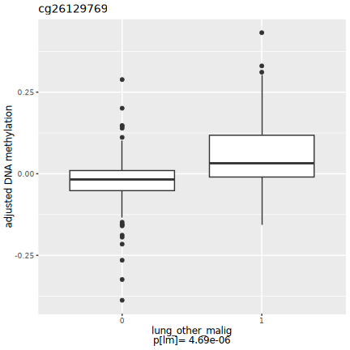

## Selected CpG sites

Number of CpG sites selected: 0.

| chromosome | position | estimate | p.value | p.adjust |
| --- | --- | --- | --- | --- |